# AnÃ¡lise de Jogadores

## Vamos observar o PER, agrupando por times, podemos ver quais são os melhores?

O PER é uma estatistica relativamente antiga, ela mede a eficiencia do jogador em quadra. Embora muito criticada por substimar jogadores que tem mais habilidades defensivas do ofensivas, ainda é muito utilizada para comparar jogadores.

Vamos ver como os times estão em relação ao PER de seus jogadores nessa temporada.

Primeiro vamos ver como estão distribuidos o PER dos jogadores, com o fim de definir uma medida de posição eficiente para avaliar os times.

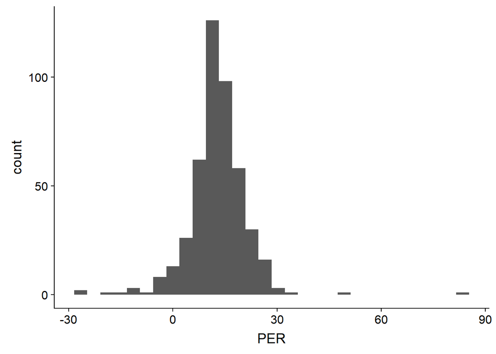

```r
players_adv %>%
  ggplot(aes(x = PER))+
  geom_histogram(bins = 30)
```

Vemos alguma incosistencia nos dados, tem alguem com o PER perto de 90 e isso é inviavel. O jogador com esse número só jogou apenas 1 minuto e como fez uma cesta o seu número explodiu.  
Vamos filtrar melhor os jogadores para analisar o PER. Preferi pegar jogadores que jogaram minutos acima do primeiro quartil, nesse ponto da temporada é um número reazoavel.

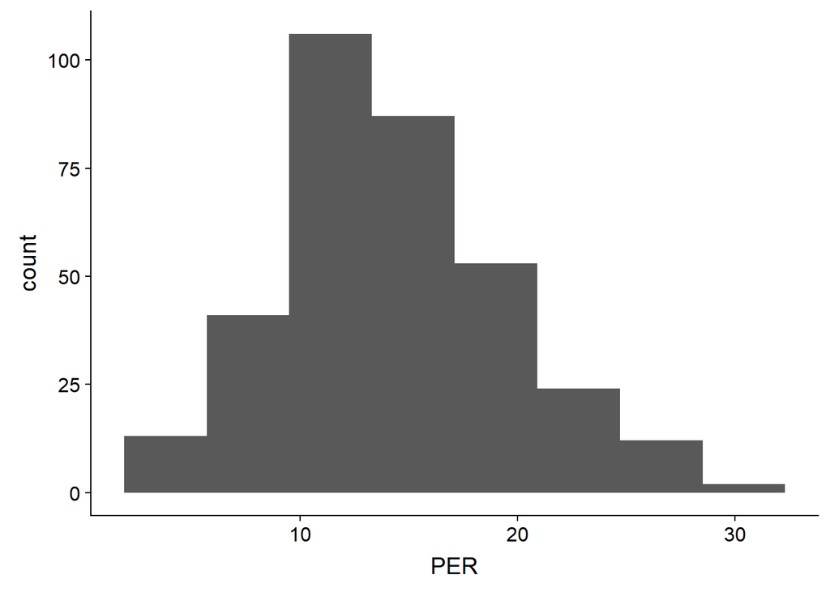

```r
players_adv %>%
  filter(MP >= quantile(MP, 0.25)) %>%
  ggplot(aes(x = PER))+
  geom_histogram(bins = 8)
```

O PER é centrado na média, mas existe um desvio pesado. Vamos usar a média mesmo assim, entretanto vamos adicionar uma medida de dispersão para analisar os times.

```r
players_adv %>%
  filter(MP >= quantile(MP, 0.25)) %>%
  group_by(Tm) %>%
  filter(!(Tm == "TOT")) %>% # TIRANDO A GALERA SEM TIME
  summarise(per_med = mean(PER), per_sd = sd(PER)) %>%
  arrange(desc(per_med))
```

```
## # A tibble: 30 x 3
##    Tm    per_med per_sd
##    <chr>   <dbl>  <dbl>
##  1 MIL      16.5   4.94
##  2 LAC      16.4   7.73
##  3 CHO      16.4   4.75
##  4 GSW      16.1   5.60
##  5 POR      15.6   6.31
##  6 IND      15.6   4.95
##  7 LAL      15.2   6.22
##  8 OKC      15.1   7.04
##  9 DEN      15.1   4.99
## 10 SAS      15.0   4.76
## # ... with 20 more rows
```

Como esperado, Os melhores times até agora da temporada estão com o PER médio maior entre seus jogadores.  
Vamos fazer uma viz com esses dados!.

[figure not shown]

```r
nbaTeams=c("ATL","BOS","BKN","CHA","CHI","CLE","DAL","DEN","DET","GSW",
           "HOU","IND","LAC","LAL","MEM","MIA","MIL","MIN","NOP","NYK",
           "OKC","ORL","PHI","PHX","POR","SAC","SAS","TOR","UTA","WAS")
per_team_viz <- players_adv %>%
  filter(MP >= quantile(MP, 0.25)) %>%
  filter(USG. >= quantile(USG., 0.25)) %>%
  group_by(Tm) %>%
  filter(!(Tm == "TOT")) %>% # TIRANDO A GALERA SEM TIME
  summarise(per_med = mean(PER), per_sd = sd(PER)) %>%
  mutate(logo = paste0("logo_times/",nbaTeams,".png"))
per_team_viz %>%
  ggplot(aes(x = per_med, y = per_sd, label = Tm))+
  geom_image(data = per_team_viz, aes(image = per_team_viz$logo), size = 0.12,
             by = "width")+
  coord_fixed()
```

UAU, A galera do tank está realmente proeminente, mas creio que usar a média foi um erro, alguns times não se adaptaram bem ao filtro que utilizei. Vamos observar quantos jogadores temos por time com esse filtro que estou usando.

```r
players_adv %>%
  filter(MP >= quantile(MP, 0.25)) %>%
  filter(USG. >= quantile(USG., 0.25)) %>%
  group_by(Tm) %>%
  count(sort = TRUE)
```

```
## # A tibble: 31 x 2
## # Groups:   Tm [31]
##    Tm        n
##    <chr> <int>
##  1 CLE      12
##  2 ATL      11
##  3 MIA      11
##  4 TOR      10
##  5 UTA      10
##  6 BOS       9
##  7 BRK       9
##  8 LAL       9
##  9 MEM       9
## 10 MIL       9
## # ... with 21 more rows
```